# PROYECCIÓN DE LOS ESTUDIANTES DE LA UNIVERSIDAD DE INGENIERIA Y TECNOLOGIA PARA REALIZAR ESTUDIOS DE POSGRADO EN UNIVERSIDADES DENTRO Y FUERA DEL PERÚ DURANTE EL AÑO 2023.

Grupo 8

```r
library(htmltools)
```

*“Universidad de Ingeniería y Tecnología”*

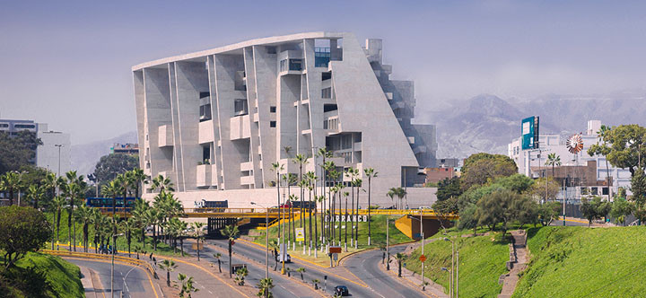

## Contenido

- ’1. Introducción’
- ’2. Relevancia’
- ’2. Objetivos’
- ’2. Contexto’
- ’2. Datos’
- ’2. Recolección de datos’
- ’2. Población, muestra y muestreo’
- ’2. Variables’
- ’2. Limpieza de base de datos’
- ’2. Análisis descriptivo’

*Preferencias de los estudiantes de UTEC para estudiar posgrado*

## **1. Tema**

> *“PROYECCIÓN DE LOS ESTUDIANTES DE LA UNIVERSIDAD DE INGENIERIA Y TECNOLOGIA PARA REALIZAR ESTUDIOS DE POSGRADO EN UNIVERSIDADES DENTRO Y FUERA DEL PERÚ DURANTE EL AÑO 2023.”*
- Título corto: *“Universidades preferidas de los estudiantes de UTEC para estudiar Posgrado”*

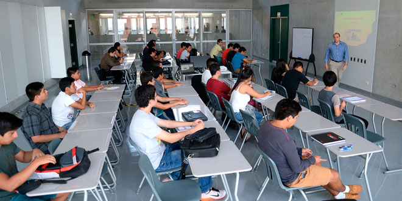

# 1. INTRODUCCION

## **1.1 Relevancia**

Los estudiantes de UTEC que desean estudiar posgrado, pueden aprovechar la reputación y las conexiones de la universidad para estudiar en otras universidades dentro y fuera del Perú, ampliando sus perspectivas académicas y profesionales. La UTEC tiene alianzas con universidades prestigiosas en todo el mundo, brindando oportunidades de contactos internacionales. La demanda de profesionales capacitados en ingeniería y tecnología sigue en aumento, lo que ofrece buenas perspectivas de empleo para los estudiantes de posgrado de la UTEC, tanto dentro como fuera del Perú. La UTEC se adapta a las demandas del mercado laboral y ofrece programas relevantes y actualizados para las necesidades empresariales. Hacer un posgrado en Perú puede ser beneficioso por la familiaridad con la universidad y la economía en comparación con estudiar en el extranjero. Además, permite mantenerse cerca de amigos, familiares y redes de contacto establecidas. Sin embargo, hacer un posgrado en el extranjero brinda una valiosa experiencia internacional, expandiendo la perspectiva y las habilidades interculturales del estudiante. También ofrece la oportunidad de establecer contactos internacionales y desarrollar habilidades de networking útiles para futuros proyectos empresariales. En resumen, la elección de hacer un posgrado en Perú o en el extranjero depende de los objetivos, preferencias y circunstancias financieras del estudiante. Ambas opciones tienen ventajas y desventajas, y es importante considerar cuidadosamente todas las opciones y tomar una decisión informada para el futuro.

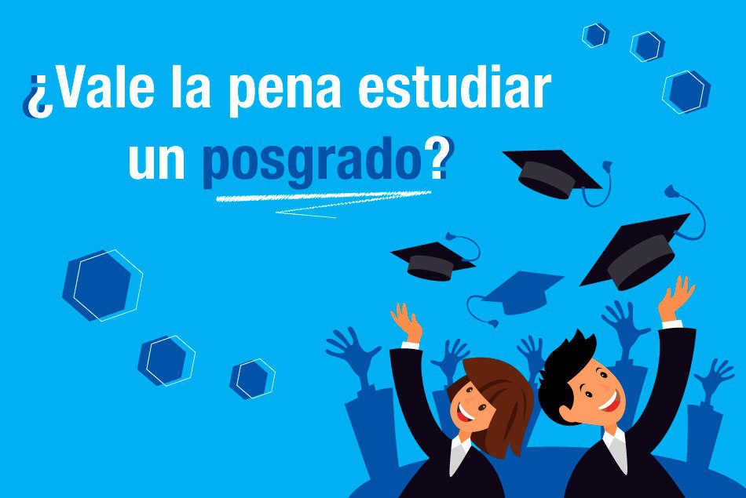

## **1.2 Objetivos**

### **1.2.1 Objetivos General:**

Investigar las universidades más preferidas por los estudiantes de todas las carreras de la Universidad de Ingeniería y Tecnología para continuar sus estudios de pregrado, tanto en el país como en el extranjero durante el año 2023.

### **1.2.2 Objetivos Específicos:**

1. Cuantificar la cantidad de estudiantes de la Universidad de Ingeniería y Tecnología según su carrera y año de ingreso, que planean o no continuar sus estudios de posgrado en el país y en el extranjero durante el año 2023.
2. Identificar y analizar los factores personales, académicos y económicos que influyen directa e indirectamente en la decisión de los estudiantes de la Universidad de Ingeniería y Tecnología de continuar sus estudios de posgrado durante el año 2023.
3. Examinar las preferencias de los estudiantes de la Universidad de Ingeniería y Tecnología por universidades nacionales y extranjeras según carrera que están estudiando para continuar sus estudios de posgrado durante el año 2023.
4. Evaluar el nivel de conocimiento y comprensión de los estudiantes de la Universidad de Ingeniería y Tecnología sobre los procesos necesarios para continuar sus estudios de posgrado.

## **1.2 CONTEXTO**

> El panorama educativo ha experimentado una evolución significativa en los últimos años, impulsado por la creciente demanda de educación de posgrado como una forma de mejorar las habilidades y el conocimiento especializado. En este contexto, la Universidad de Ingeniería y Tecnología (UTEC) se ha establecido como una institución líder en la formación de profesionales altamente capacitados y reconocidos en el ámbito académico y laboral.

# 2. Datos

## **2.1 RECOLECCION DE DATOS**

Para este estudio, recolectamos datos mediante una encuesta aleatoria en el campus universitario. Durante los primeros días de la recolección, visitamos las áreas de esparcimiento de la universidad, donde era más probable encontrar estudiantes desocupados o descansando. Elegimos este lugar y momento para no interrumpir otras actividades que los entrevistados podrían estar realizando.

[Imagen para la recoleccion de datos]

[figure not shown]

A continuación adjunto el enlace de la encuesta. [Link de a encuesta](https://docs.google.com/forms/d/13vfyWL8injovxnEG2jghNKMo0cZBDxG8uDG2dp5DjGI/edit?ts=644138a6)

## **2.2 POBLACION**

Nuestra población de estudios fueron todos los estudiantes de la UTEC matriculados en el ciclo 2023-1

## **2.4 UNIDAD MUESTRAL**

La unidad muestral fue cada estudiante de la UTEC matriculado en el ciclo 2023-1

## **2.5 MUESTREO**

Se utilizo un muestreo aleatorio simple a cualquier estudiante que se encuentre en la UTEC

## **2.6 VARIABLES**

MOSTRAMOS LAS VARIABLE DE NUESTRA BASE DE DATOS EN UNA TABLA

*Variables del proyecto:*

| Variable | Tipo de Varible | Restricciones |
| --- | --- | --- |
| Carrera | Cualitativa nominal | Nombre de su carera |
| Genero | Cualitativa nominal | Masculino / Femenino |
| Edad | Cuantitaviva discreta | Entero Positivo(15-40) |
| Ciclo | Cuantitativa discreta | Entero positivo (1-10) |
| O_merito | Cualitaviva ordinal | Medio,Tercio,Quinto,Decimo,Primeros |
| Cachimbo | Cualitativa ordinal | ciclo(20- 18/19/20/21/22/23) |
| Promedio | Cuantitativa continua | Cualquier valor entre (0-20) |
| Condi_socio | Cualitativa ordinal | Alto/Medio Alto/Medio Bajo/Medio/Bajo |
| Ingreso_mensualITO | Cuantitativa discreta | Entero positivo(1200-6000<) |
| Realiza_Posgrado | Cualitativa nominal | Si / No |
| Peru_o_extranjero | Cualitativa nominal | Perú / Extranjero |
| U_del_Peru | Cualitativa nominal | Nombre de su Universidad Peruana |
| Modalidad_ExtrangeroS | Cualitativa nominal | Con una beca/Yo solventaré los gastos |
| gastos_mensuales_soles | Cualitativa ordinal | soles(0 a 5000:de 1000 en 1000) |
| U_del_Extran | Cualitativa nominal | Nombre de su Universidad Extranjera |
| gastos_mensuales_dolares | Cualitativa ordinal | Valores Dolares(0 a 5000:1000 en 1000) |
| gastos_viaje | Cualitativa nominal | Si / NO |
| Modalidad_peru | Cualitativa nominal | Con una beca/Yo solventaré los gastos |
| Conoce_procesos | Cualitativa nominal | Si/ No / Un poco |

## **2.7 Limpieza de datos**

```r
library(readr)
library(dplyr)
library(DescTools)
library(raster)
```

## Leyendo el archivo

```r
ZZ <- read_csv("LuneraU.csv")
```

```
## -------------------------------------------------------- Delimiter: "," chr
## (15): Marca temporal, Dirección de correo electrónico, ¿Qué carrera estu... dbl
## (7): Código de alumno:, Edad :, ¿Ciclo que cursas?, Año que ingresaste ... lgl
## (1): ¿Tienes conocimientos procesos que se siguen para continuar estudi...
```

```r
ZZ
```

| Marca temporal | Dirección de correo electrónico | ¿Qué carrera estudias? | Código de alumno: | Género : | Edad : | ¿Ciclo que cursas? | Orden de mérito de tu carrera | Año que ingresaste a UTEC: | Promedio ponderado obtenido en tu último ciclo regular: | Condición socioeconómica | Ingreso mensual aproximado que percibe tu familia: | ¿Realizarás estudios de postgrado al terminar tu carrera? | ¿Dónde realizarás tu postgrado? | ¿En que Universidad del Perú pretendes estudiar tu postgrado? | Modalidad de estudio de Posgrado...16 | ¿Cuánto crees que gastarás en tus estudios de postgrado mensualmente?(en soles) | ¿En que universidad del extranjero pretendes estudiar tu postgrado? | ¿Cuánto crees que gastarás en tus estudios de postgrado mensualmente?(cifra en dólares) | ¿Sabes cuánto aproximadamente gastarías en un viaje a la universidad que pretendes estudiar posgrado? Incluyendo boletos de avión, alojamiento, transporte local, alimentación y otros gastos imprevisto… | Modalidad de estudio de Posgrado...21 | Conoces sobre los procesos que se siguen para realizar estudio de posgrado? | ¿Tienes conocimientos procesos que se siguen para continuar estudios de postgrado? |
| --- | --- | --- | --- | --- | --- | --- | --- | --- | --- | --- | --- | --- | --- | --- | --- | --- | --- | --- | --- | --- | --- | --- |
| 24/04/2023 11:00:59 | jose.ostos@utec.edu.pe | Ingeniería Electrónica | 202120415 | Masculino | 20 | 4 | Tercio Superior | 2021 | 14.39 | Bajo | 1200 | Sí | Extranjero | NA | NA | NA | MIT | 4500 | Si | Con una beca | Si | NA |
| 24/04/2023 11:44:17 | fabrizzio.vilchez.e@utec.edu.pe | Ciencia de la Computación | 202210534 | Masculino | 18 | 3 | Décimo Superior | 2022 | 17.1 | Medio Bajo | 2000 | Sí | Extranjero | NA | NA | NA | UPM | 4000 | Si | Con una beca | No | NA |
| 28/04/2023 21:51:41 | marco.pillaca@utec.edu.pe | Ingeniería Electrónica | 202120555 | Masculino | 19 | 4 | Décimo Superior | 2021 | 14 | Bajo | 1200 | Sí | Perú | PUCP | Con una beca | 5000 | NA | NA | NA | NA | Si | NA |
| 24/04/2023 12:11:44 | fatima.jara@utec.edu.pe | Bioingeniería | 202120301 | Femenino | 20 | 4 | Quinto Superior | 2019 | 18 | Medio Bajo | 2000 | Sí | Extranjero | NA | NA | NA | MIT | 5000 | No | Con una beca | No | NA |
| 27/04/2023 8:13:55 | carlos.santiesteban@utec.edu.pe | Ingeniería Civil | 202120529 | Masculino | 20 | 4 | Tercio Superior | 2021 | 16.57 | Medio Bajo | 2000 | Sí | Perú | UTEC | Yo solventare todos los gastos | 3000 | NA | NA | NA | NA | No | NA |
| 27/04/2023 1:17:06 | erick.condori@utec.edu.pe | Ingeniería Civil | 202120172 | Masculino | 20 | 4 | Tercio Superior | 2021 | 14 | Medio | 2500 | Sí | Perú | UPC | Yo solventare todos los gastos | 3000 | NA | NA | NA | NA | No | NA |
| 25/04/2023 22:52:59 | mario.alvarez@utec.edu.pe | Ingeniería Mecatrónica | 202310392 | Masculino | 17 | 1 | Tercio Superior | 2023 | 0 | Medio | 3000 | Sí | Extranjero | NA | NA | NA | HU | 5000 | Si | Yo solventare todos los gastos | Si | NA |
| 26/04/2023 10:44:02 | emilio.pena@utec.edu.pe | Ingeniería Mecánica | 201320054 | Masculino | 21 | 7 | Medio Superior | 2019 | 14 | Medio | 2500 | Sí | Extranjero | NA | NA | NA | MIT | 4000 | Si | Con una beca | Si | NA |
| 29/04/2023 22:35:26 | joseph.roca.c@utec.edu.pe | Ingeniería Civil | 202120015 | Masculino | 19 | 4 | Tercio Superior | 2021 | 16.75 | Medio Bajo | 2000 | Sí | Extranjero | NA | NA | NA | MIT | 2500 | No | Con una beca | No | NA |
| 26/04/2023 18:07:03 | jefferson.peralta@utec.edu.pe | Ingeniería Industrial | 202120429 | Masculino | 19 | 6 | Tercio Superior | 2021 | 16.34 | Medio Alto | 3100 | Sí | Extranjero | NA | NA | NA | UDK | 4000 | Si | Con una beca | Si | NA |

[output cut: 212 more lines]

```r
library(dplyr)
```

**Eliminamos las variables que no nos sirven para mi estudio estadistico**

```r
ZZ <- ZZ[, c(3, 5:23)]
```

### A CONTINUACION VAMOS A CORREGIR EL NOMBRE DE LAS VARIABLES A UNOS NOMBRES MAS MANEJABLES

**CARRERA**

```r
ZZ <- rename(ZZ,Carrera = '¿Qué carrera estudias?')
```

**GENERO**

```r
ZZ <- rename(ZZ, Genero = 'Género :')
```

**EDAD**

```r
ZZ<- rename(ZZ,Edad = 'Edad :')
```

**CICLO**

```r
ZZ <- rename(ZZ, Ciclo = '¿Ciclo que cursas?')
```

**ORDEN DDE MERITO**

```r
ZZ <- rename(ZZ, O_merito = 'Orden de mérito de tu carrera')
```

**AÑO DE INGRESO**

```r
ZZ <- rename(ZZ, Cachimbo = 'Año que ingresaste a UTEC:')
```

**PROMEDIO PONDERADO**

```r
ZZ <- rename(ZZ,Promedio = 'Promedio ponderado obtenido en tu último ciclo regular:')
```

**CONDICION SOCIOECONOMICA**

```r
ZZ <- rename(ZZ, Condi_socio = 'Condición socioeconómica')
```

**INGRESO MENSUAL**

```r
ZZ <- rename(ZZ,Ingreso_mensualITO = 'Ingreso mensual aproximado que percibe tu familia:' )
```

**¿REALIZA POSGRADO?** ´

```r
ZZ <- rename(ZZ, Realiza_Posgrado = '¿Realizarás estudios de postgrado al terminar tu carrera?')
```

**PERU O EXTRANJERO**

```r
ZZ <- rename(ZZ, Peru_o_extrangero = '¿Dónde realizarás tu postgrado?')
```

**UNNIVERSIDAD DEL PERU**

```r
ZZ <- rename(ZZ, U_del_Peru = '¿En que Universidad del Perú pretendes estudiar tu postgrado?')
```

**MODADLIDAD DEL PERU**

```r
ZZ <- rename(ZZ, Modalidad_peru = 'Modalidad de estudio de Posgrado...16')
```

**GASTO MENSUAL EN SOLES**

```r
ZZ <- rename(ZZ, gastos_mensuales_soles = '¿Cuánto crees que gastarás en tus estudios de postgrado mensualmente?(en soles)')
```

**UNIVERSIDAD DEL EXTRANJERO**

```r
ZZ <- rename(ZZ, U_del_Extran = '¿En que universidad del extranjero pretendes estudiar tu postgrado?')
```

**MODALIDAD EN EL EXTRANJERO**

```r
ZZ <- rename(ZZ, Modalidad_ExtrangeroS = 'Modalidad de estudio de Posgrado...21')
```

```r
ZZ <- rename(ZZ, gastos_mensuales_dolares = '¿Cuánto crees que gastarás en tus estudios de postgrado mensualmente?(cifra en dólares)')
```

**GASTOS DEL VIAJE**

```r
ZZ <- rename(ZZ, gastos_viaje = '¿Sabes cuánto aproximadamente gastarías en un viaje a la universidad que pretendes estudiar posgrado? Incluyendo boletos de avión, alojamiento, transporte local, alimentación y otros gastos imprevistos.')
```

**CONOCE SOBRE LOS PROCESOS**

```r
ZZ <- rename(ZZ, Conoce_procesos = 'Conoces sobre los procesos que se siguen para realizar estudio de posgrado?')
```

```r
names(ZZ)
```

```
##  [1] "Carrera"
##  [2] "Genero"
##  [3] "Edad"
##  [4] "Ciclo"
##  [5] "O_merito"
##  [6] "Cachimbo"
##  [7] "Promedio"
##  [8] "Condi_socio"
##  [9] "Ingreso_mensualITO"
## [10] "Realiza_Posgrado"
## [11] "Peru_o_extrangero"
## [12] "U_del_Peru"
## [13] "Modalidad_peru"
## [14] "gastos_mensuales_soles"
## [15] "U_del_Extran"
## [16] "gastos_mensuales_dolares"
## [17] "gastos_viaje"
## [18] "Modalidad_ExtrangeroS"
## [19] "Conoce_procesos"
## [20] "¿Tienes conocimientos procesos que se siguen para continuar estudios de postgrado?"
```

**VERIFICANDO LOS DATOS ATIPICOS PARA LUEGO CORREGIRLOS**

```r
str(ZZ)
```

```
## tibble [222 x 20] (S3: tbl_df/tbl/data.frame)
##  $ Carrera                                                                           : chr [1:222] "Ingeniería Electrónica" "Ciencia de la Computación" "Ingeniería Electrónica" "Bioingeniería" ...
##  $ Genero                                                                            : chr [1:222] "Masculino" "Masculino" "Masculino" "Femenino" ...
##  $ Edad                                                                              : num [1:222] 20 18 19 20 20 20 17 21 19 19 ...
##  $ Ciclo                                                                             : num [1:222] 4 3 4 4 4 4 1 7 4 6 ...
##  $ O_merito                                                                          : chr [1:222] "Tercio Superior" "Décimo Superior" "Décimo Superior" "Quinto Superior" ...
##  $ Cachimbo                                                                          : num [1:222] 2021 2022 2021 2019 2021 ...
##  $ Promedio                                                                          : chr [1:222] "14.39" "17.1" "14" "18" ...
##  $ Condi_socio                                                                       : chr [1:222] "Bajo" "Medio Bajo" "Bajo" "Medio Bajo" ...
##  $ Ingreso_mensualITO                                                                : num [1:222] 1200 2000 1200 2000 2000 2500 3000 2500 2000 3100 ...
##  $ Realiza_Posgrado                                                                  : chr [1:222] "Sí" "Sí" "Sí" "Sí" ...
##  $ Peru_o_extrangero                                                                 : chr [1:222] "Extranjero" "Extranjero" "Perú" "Extranjero" ...
##  $ U_del_Peru                                                                        : chr [1:222] NA NA "PUCP" NA ...
##  $ Modalidad_peru                                                                    : chr [1:222] NA NA "Con una beca" NA ...
##  $ gastos_mensuales_soles                                                            : num [1:222] NA NA 5000 NA 3000 3000 NA NA NA NA ...
##  $ U_del_Extran                                                                      : chr [1:222] "MIT" "UPM" NA "MIT" ...
##  $ gastos_mensuales_dolares                                                          : num [1:222] 4500 4000 NA 5000 NA NA 5000 4000 2500 4000 ...
##  $ gastos_viaje                                                                      : chr [1:222] "Si" "Si" NA "No" ...
##  $ Modalidad_ExtrangeroS                                                             : chr [1:222] "Con una beca" "Con una beca" NA "Con una beca" ...
##  $ Conoce_procesos                                                                   : chr [1:222] "Si" "No" "Si" "No" ...
##  $ ¿Tienes conocimientos procesos que se siguen para continuar estudios de postgrado?: logi [1:222] NA NA NA NA NA NA ...
```

**PASANDO A NUMERICA LA VARIABLE PROMEDIO**

```r
ZZ$Promedio <- as.numeric(ZZ$Promedio)
```

**ELIMINANDO LOS DATOS ATIPICOS DE LA VARIABLE PROMEDIO**

```r
# Obtener las posiciones de los valores deseados
posiciones <- which(ZZ$Promedio == 1.00 | ZZ$Promedio == 0.00 | is.na(ZZ$Promedio))
posiciones
```

```
## [1]   7  31  96 116 145
```

```r
#A continuacion eliminamos las variables de esa posicion

ZZ <- ZZ[-c(posiciones), ]
```

**VAMOS CON LA VARIABLE CARRERA**

```r
ZZ$Carrera  #ESTA VARIABLE NO TIENE  DATOS ATIPICOS PORQUE ERA PARA SELECCIONAR
```

```
##   [1] "Ingeniería Electrónica"
##   [2] "Ciencia de la Computación"
##   [3] "Ingeniería Electrónica"
##   [4] "Bioingeniería"
##   [5] "Ingeniería Civil"
##   [6] "Ingeniería Civil"
##   [7] "Ingeniería Mecánica"
##   [8] "Ingeniería Civil"
##   [9] "Ingeniería Industrial"
##  [10] "Ingeniería Civil"
##  [11] "Ingeniería Industrial"
##  [12] "Ingeniería Civil"
##  [13] "Ingeniería Industrial"
##  [14] "Ingeniería Civil"
##  [15] "Ingeniería Química"
```

[output cut: 202 more lines]

```r
ZZ$Genero #NO PRESENTA DATOS ATIPICOS NI NA
```

```
##   [1] "Masculino" "Masculino" "Masculino" "Femenino"  "Masculino" "Masculino"
##   [7] "Masculino" "Masculino" "Masculino" "Masculino" "Masculino" "Masculino"
##  [13] "Femenino"  "Masculino" "Femenino"  "Femenino"  "Masculino" "Femenino"
##  [19] "Masculino" "Femenino"  "Masculino" "Femenino"  "Femenino"  "Masculino"
##  [25] "Femenino"  "Masculino" "Femenino"  "Femenino"  "Masculino" "Masculino"
##  [31] "Masculino" "Masculino" "Femenino"  "Femenino"  "Masculino" "Femenino"
##  [37] "Femenino"  "Femenino"  "Masculino" "Masculino" "Masculino" "Femenino"
##  [43] "Femenino"  "Masculino" "Femenino"  "Femenino"  "Masculino" "Masculino"
##  [49] "Masculino" "Masculino" "Masculino" "Masculino" "Masculino" "Femenino"
##  [55] "Femenino"  "Masculino" "Femenino"  "Femenino"  "Masculino" "Masculino"
##  [61] "Masculino" "Masculino" "Masculino" "Femenino"  "Femenino"  "Masculino"
##  [67] "Masculino" "Masculino" "Masculino" "Femenino"  "Masculino" "Masculino"
##  [73] "Masculino" "Femenino"  "Masculino" "Masculino" "Femenino"  "Masculino"
##  [79] "Masculino" "Femenino"  "Femenino"  "Femenino"  "Femenino"  "Masculino"
##  [85] "Masculino" "Masculino" "Masculino" "Masculino" "Masculino" "Femenino"
```

[output cut: 22 more lines]

```r
ZZ$Edad #NO HAY DATOS ATIPICOS
```

```
##   [1] 20 18 19 20 20 20 21 19 19 22 19 32 19 19 18 19 20 20 19 18 22 21 18 19 20
##  [26] 24 19 20 20 22 21 18 20 19 22 20 20 17 19 21 20 19 21 20 18 20 21 27 17 20
##  [51] 18 19 19 20 23 20 22 20 18 23 23 20 23 20 18 21 18 21 19 21 19 15 21 18 20
##  [76] 20 19 23 20 19 18 21 21 18 21 21 20 19 20 21 21 25 19 24 19 19 20 20 21 19
## [101] 19 21 19 19 20 22 19 15 18 18 19 19 22 17 19 19 19 22 19 20 19 21 19 21 19
## [126] 20 18 18 17 18 18 17 19 20 19 20 20 19 20 20 18 25 19 21 19 23 26 26 18 20
## [151] 19 17 20 18 18 19 20 19 19 20 23 20 24 20 19 18 20 21 19 19 18 19 19 18 19
## [176] 22 21 19 21 20 18 18 19 18 18 21 18 24 20 20 19 19 17 18 18 21 23 20 19 19
## [201] 20 19 18 23 20 19 19 19 21 20 19 19 22 17 19 22 22
```

```r
ZZ$Ciclo #LA VARIABLE CICLO ESTA LIMPIA
```

```
##   [1]  4  3  4  4  4  4  7  4  6  4  5  4  4  4  4  4  6  4  3  4  4  4  4  4  4
##  [26]  5  4  4  4  7  5  3  4  4  4  4  4  3  4  4  5  4  4  4  3  4  4  5  2  4
##  [51]  4  5  5  4  4  7  4  9  3  3  8  6  9  4  3  9  4  5  4  4  4  4  3  3  5
##  [76]  4  5  5  4  4  2  6  4  4  6  4  4  4  5  4  9  9  4  7  2  4  4  3  6  2
## [101]  4  4  4  3  4  4  4  1  3  3  4  4  4  2  3  4  4  4  4  5  4  8  2  7  5
## [126]  6  3  3  3  2  4  3  5  5  4  4  2  2  2  2  2  8  4 10  5  6  5  5  4  8
## [151]  4  2  4  2  2  2  7  7  2  6 10  4  2  3  5  3  3  5  4  4  4  4  5  5  5
## [176]  5  6  5  5  6  2  3  2  2  2  7  4  4  7  3  4  3  2  3  3  4  5  4  4  4
## [201]  4  4  2  8  4  5  6  5  6  4  4  3  9  7  2  8  6
```

```r
ZZ$O_merito #LIMPIA
```

```
##   [1] "Tercio Superior"  "Décimo Superior"  "Décimo Superior"
##   [4] "Quinto Superior"  "Tercio Superior"  "Tercio Superior"
##   [7] "Medio Superior"   "Tercio Superior"  "Tercio Superior"
##  [10] "Medio Superior"   "Medio Superior"   "Tercio Superior"
##  [13] "Quinto Superior"  "Décimo Superior"  "Medio Superior"
##  [16] "Medio Superior"   "Quinto Superior"  "Medio Superior"
##  [19] "Tercio Superior"  "Tercio Superior"  "Tercio Superior"
##  [22] "Medio Superior"   "Medio Superior"   "Medio Superior"
##  [25] "Medio Superior"   "Medio Superior"   "Tercio Superior"
##  [28] "Décimo Superior"  "Quinto Superior"  "Medio Superior"
##  [31] "Tercio Superior"  "Décimo Superior"  "Tercio Superior"
##  [34] "Medio Superior"   "Medio Superior"   "Medio Superior"
##  [37] "Tercio Superior"  "Décimo Superior"  "Tercio Superior"
##  [40] "Medio Superior"   "Quinto Superior"  "Medio Superior"
##  [43] "Tercio Superior"  "Quinto Superior"  "Tercio Superior"
```

[output cut: 58 more lines]

```r
ZZ$Cachimbo #NO HAY  DATOS ATIPICOS
```

```
##   [1] 2021 2022 2021 2019 2021 2021 2019 2021 2021 2021 2021 2021 2021 2021 2021
##  [16] 2021 2021 2021 2022 2021 2021 2021 2021 2021 2021 2021 2021 2021 2021 2018
##  [31] 2021 2022 2021 2021 2021 2020 2021 2022 2021 2021 2021 2021 2021 2021 2022
##  [46] 2021 2021 2017 2022 2021 2021 2021 2021 2021 2021 2020 2021 2019 2022 2022
##  [61] 2018 2020 2017 2021 2022 2019 2021 2020 2021 2021 2021 2021 2022 2022 2021
##  [76] 2021 2021 2021 2021 2021 2022 2019 2021 2021 2020 2018 2021 2021 2021 2021
##  [91] 2019 2017 2021 2019 2022 2021 2023 2022 2019 2022 2021 2021 2021 2021 2021
## [106] 2021 2021 2023 2022 2022 2021 2021 2021 2022 2021 2021 2021 2021 2021 2020
## [121] 2021 2019 2022 2019 2021 2019 2022 2022 2022 2022 2021 2022 2021 2021 2020
## [136] 2021 2022 2022 2022 2022 2022 2017 2021 2018 2021 2018 2022 2021 2021 2019
## [151] 2021 2022 2020 2022 2022 2022 2022 2020 2022 2021 2017 2021 2022 2022 2020
## [166] 2021 2020 2019 2022 2021 2021 2021 2020 2021 2019 2018 2020 2020 2021 2021
## [181] 2022 2022 2022 2022 2022 2020 2021 2022 2020 2022 2019 2021 2022 2022 2022
## [196] 2021 2018 2021 2020 2020 2021 2021 2022 2019 2021 2021 2021 2021 2020 2020
## [211] 2020 2021 2017 2022 2021 2019 2020
```

```r
unique(ZZ$Cachimbo)
```

```
## [1] 2021 2022 2019 2018 2020 2017 2023
```

```r
ZZ$Promedio #LIMPIA
```

```
##   [1] 14.39 17.10 14.00 18.00 16.57 14.00 14.00 16.75 16.34 14.30 16.00 13.90
##  [13] 14.45 11.00 13.52 13.50 16.05 12.00 14.50 13.61 15.45 12.00 13.00 14.20
##  [25] 12.00 15.00 14.52 16.40 16.00 12.04 15.00 10.00 15.00 13.54 13.68 13.85
##  [37] 15.20 17.45 14.63 12.80 18.33 14.84 16.75 15.00 17.00 14.50 12.33 14.00
##  [49] 16.92 15.01 15.60 13.70 15.00 14.00 14.00 13.00 13.45 18.45 15.00 12.40
##  [61] 15.60 14.60 17.00 14.80 16.00 15.17 15.30 15.50 14.15 14.76 13.50 13.67
##  [73] 16.50 18.00 14.00 13.98 16.50 13.60 16.95 14.67 14.00 14.50 15.80 14.14
##  [85] 11.05 15.30 15.47 14.60 13.00 15.00 16.58 14.50 16.80 17.30 17.10 16.70
##  [97] 12.00 14.52 13.10 16.90 14.09 13.00 16.23 12.50 15.40 14.75 11.00 19.99
## [109] 13.07 18.75 15.00 14.00 14.33 14.00 14.00 15.00 16.00 16.00 13.70 12.58
## [121] 15.00 17.00 15.00 14.60 12.54 12.00 13.00 16.07 12.41 16.00 14.60 17.00
## [133] 16.00 15.20 14.00 15.14 15.68 13.50 16.00 16.00 16.10 13.10 14.80 15.00
## [145] 16.57 16.00 15.70 19.00 15.00 16.00 16.00 17.00 13.00 16.53 16.33 14.00
## [157] 15.67 17.38 16.40 15.00 14.40 14.00 17.10 14.00 16.00 16.00 14.00 11.00
## [169] 14.00 13.00 15.00 16.50 13.00 14.15 14.53 17.00 15.60 15.00 15.82 19.00
## [181] 16.00 14.45 17.10 15.70 15.85 12.33 14.50 13.17 13.12 14.35 15.00 15.56
## [193] 15.00 15.41 15.61 14.00 14.00 13.00 12.34 14.00 14.00 14.45 15.85 15.00
## [205] 14.60 15.00 14.36 15.54 14.30 13.20 14.00 11.00 16.40 13.00 17.00 14.50
## [217] 16.45
```

```r
ZZ$Condi_socio #ESTA VARIABLE ERA PARA SELECIONAR NO HAY ERRORES NI DATOS ATIPICOS NI NA PORQUE ERA OBLIGATORIO RESPONDER PARA EL ENCUUESTADO
```

```
##   [1] "Bajo"       "Medio Bajo" "Bajo"       "Medio Bajo" "Medio Bajo"
##   [6] "Medio"      "Medio"      "Medio Bajo" "Medio Alto" "Bajo"
##  [11] "Medio Bajo" "Medio Bajo" "Medio Bajo" "Bajo"       "Bajo"
##  [16] "Medio Bajo" "Medio Bajo" "Medio Bajo" "Bajo"       "Medio"
##  [21] "Bajo"       "Bajo"       "Medio Bajo" "Bajo"       "Bajo"
##  [26] "Bajo"       "Medio Bajo" "Medio Bajo" "Medio"      "Medio"
##  [31] "Medio"      "Medio"      "Medio"      "Bajo"       "Bajo"
##  [36] "Medio Alto" "Medio Bajo" "Medio Bajo" "Bajo"       "Medio"
##  [41] "Medio"      "Medio Bajo" "Medio"      "Medio"      "Medio"
##  [46] "Bajo"       "Medio Bajo" "Medio"      "Bajo"       "Medio"
##  [51] "Medio Bajo" "Medio"      "Medio"      "Bajo"       "Bajo"
##  [56] "Medio Alto" "Medio Bajo" "Bajo"       "Medio"      "Medio Bajo"
##  [61] "Medio"      "Bajo"       "Medio Bajo" "Medio Bajo" "Medio Bajo"
##  [66] "Medio"      "Bajo"       "Medio Bajo" "Medio"      "Bajo"
##  [71] "Bajo"       "Medio"      "Medio"      "Medio"      "Medio Alto"
```

[output cut: 29 more lines]

```r
unique(ZZ$Condi_socio)
```

```
## [1] "Bajo"       "Medio Bajo" "Medio"      "Medio Alto" "Alto"
```

```r
ZZ$Ingreso_mensualITO #SIN NA'S ERA PARA SELECCIONAR
```

```
##   [1]  1200  2000  1200  2000  2000  2500  2500  2000  3100  1200  1600  2000
##  [13]  1600  1200  1200  2000  1600  1800  1200  2500  1200  1200  2000  1200
##  [25]  1200  1200  1600  1800  3000  3000  2500  2500  2500  1200  1200  3100
##  [37]  1600  2000  1200  2500  3000  1600  2500  3000  3000  1200  2000  2500
##  [49]  1200  3000  2000  2500  3000  1200  1200  5100  1800  1200  2500  1600
##  [61]  3000  1200  1800  1600  1800  3000  1200  1600  2500  1200  1200  3000
##  [73]  2500  2500  4100  2500  3000  1200  3000  2000  2500  3000  2000  1200
##  [85]  1200  3000  1600  2500  1200  1200  1800  2500  2000  1600  1800  1200
##  [97]  1800  4100  2500  1200  1800  3000  2000  1200  2000  1200  1200  1200
## [109]  2500  2000  1200  1200  3000  2500  1200  1800  3000  2800  1600  2000
## [121]  2800  4100  1200  2800  1800  2800  5100  9100  3100  2800  1600  1800
## [133]  1800  3100  2800  2000  2800  1200  1200  1200  2800  1600  2800  1600
## [145]  2800  2800  1200 12100  1800  2800  2800  1200  2800  2800  1200  1800
## [157]  4100  2500  2000  2800  5100  3000  1200  1600  4100  2500  1200  3100
## [169]  1200  3100  2500  2500  2800  4100  1800  1800  1800  5100  6100  6100
## [181]  1200  2500  1600  3000  3000  9100  1800  2800  2000  3000  1200  3000
## [193]  1200  2500  2800  1200  2500  1800  1800  2500  2000  2500  1800  3000
## [205]  1200  1800  1200  3000  2000  2000  2800  1800  3000  1600  2800  2500
## [217]  2500
```

```r
unique(ZZ$Ingreso_mensualITO)
```

```
##  [1]  1200  2000  2500  3100  1600  1800  3000  5100  4100  2800  9100 12100
## [13]  6100
```